# Tour de France - Animated bar plot

Andrea Scalco

09/04/2020

### Weekly objective

Given that this week the data is from the Tour de France and it contains information about each edition’s winner, I thought about plotting the number of victories by each nation. Then, animate the plot to show the number of victories over the editions.

## Packages

```r
# To manipulate data
library(dplyr)
# To create and animate plots
library(ggplot2)
library(gganimate)
# To add custom images to plots
library(ggimage)
```

## Data retrieve

```r
# TidyTuesday (tt) main repo
tt_git_url <- "https://raw.githubusercontent.com/rfordatascience/tidytuesday/master/data/2020"

# 2020.04.04 datasets
tdf_winners <- readr::read_csv(paste(tt_git_url, "2020-04-07/tdf_winners.csv", sep="/"))
# Inspect data
glimpse(tdf_winners)
```

```
## Rows: 106
## Columns: 19
## $ edition       <dbl> 1, 2, 3, 4, 5, 6, 7, 8, 9, 10, 11, 12, 13, 14, 15, 16...
## $ start_date    <date> 1903-07-01, 1904-07-02, 1905-07-09, 1906-07-04, 1907...
## $ winner_name   <chr> "Maurice Garin", "Henri Cornet", "Louis Trousselier",...
## $ winner_team   <chr> "La Française", "Conte", "Peugeot–Wolber", "Peugeot–W...
## $ distance      <dbl> 2428, 2428, 2994, 4637, 4488, 4497, 4498, 4734, 5343,...
## $ time_overall  <dbl> 94.55389, 96.09861, NA, NA, NA, NA, NA, NA, NA, NA, 1...
## $ time_margin   <dbl> 2.98916667, 2.27055556, NA, NA, NA, NA, NA, NA, NA, N...
## $ stage_wins    <dbl> 3, 1, 5, 5, 2, 5, 6, 4, 2, 3, 1, 1, 1, 4, 2, 0, 3, 4,...
## $ stages_led    <dbl> 6, 3, 10, 12, 5, 13, 13, 3, 13, 13, 8, 15, 2, 14, 14,...
## $ height        <dbl> 1.62, NA, NA, NA, NA, NA, 1.78, NA, NA, NA, NA, NA, N...
## $ weight        <dbl> 60, NA, NA, NA, NA, NA, 88, NA, NA, NA, NA, NA, NA, N...
## $ age           <dbl> 32, 19, 24, 27, 24, 25, 22, 22, 26, 23, 23, 24, 33, 3...
## $ born          <date> 1871-03-03, 1884-08-04, 1881-06-29, 1879-06-05, 1882...
## $ died          <date> 1957-02-19, 1941-03-18, 1939-04-24, 1907-01-25, 1917...
## $ full_name     <chr> NA, NA, NA, NA, "Lucien Georges Mazan", "Lucien Georg...
## $ nickname      <chr> "The Little Chimney-sweep", "Le rigolo (The joker)", ...
## $ birth_town    <chr> "Arvier", "Desvres", "Paris", "Moret-sur-Loing", "Ple...
## $ birth_country <chr> "Italy", "France", "France", "France", "France", "Fra...
## $ nationality   <chr> " France", " France", " France", " France", " France"...
```

## Data wrangle: prepare the dataset for bar plots

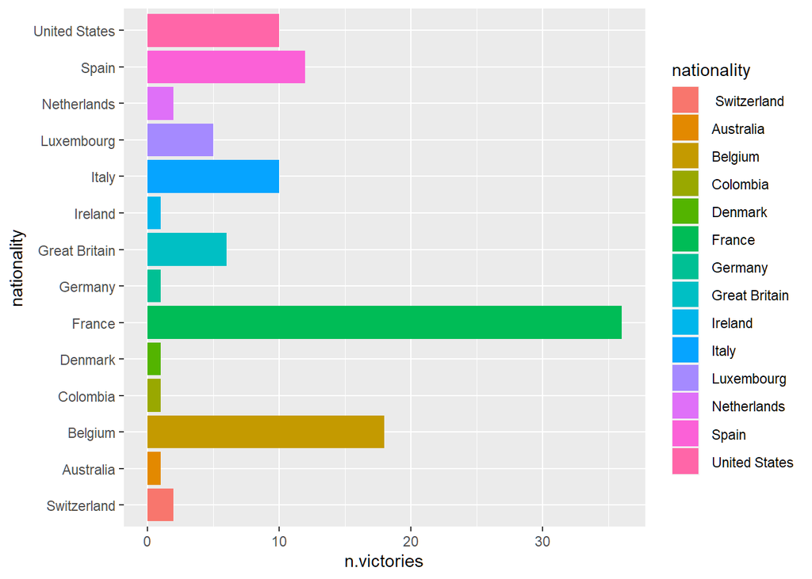

```r
# This returns the number of victories at the present time
tdf_winners %>%
  group_by(nationality) %>%
  summarise(n.victories = n()) %>%
  ggplot(aes(x=nationality, y=n.victories)) +
  geom_col(aes(fill=nationality)) +
  coord_flip()
```

To build an animation from the first to the last edition of the number of victories, I need to get this kind of table done for each edition in a single dataset. I can select specific editions by filtering them:

```r
# I can get in this way the victories for a specific range of editions
# Only the first 2 editions
tdf_winners %>%
  filter(edition %in% c(1:2)) %>%
  group_by(nationality) %>%
  summarise(n.victories = n())
```

```
## # A tibble: 1 x 2
##   nationality n.victories
##   <chr>             <int>
## 1  France               2
```

```r
# Only the first 7 editions
tdf_winners %>%
  filter(edition %in% c(1:7)) %>%
  group_by(nationality) %>%
  summarise(n.victories = n())
```

```
## # A tibble: 2 x 2
##   nationality n.victories
##   <chr>             <int>
## 1  France               6
## 2  Luxembourg           1
```

```r
# Only from the last 10 editions
tdf_winners %>%
  filter(edition %in% c(max(edition)-10:max(edition))) %>%
  group_by(nationality) %>%
  summarise(n.victories = n())
```

```
## # A tibble: 11 x 2
##    nationality    n.victories
##    <chr>                <int>
##  1   Switzerland            2
##  2  Belgium                18
##  3  Denmark                 1
##  4  France                 36
##  5  Germany                 1
##  6  Ireland                 1
##  7  Italy                   9
##  8  Luxembourg              4
##  9  Netherlands             2
## 10  Spain                  12
## 11  United States          10
```

Now, a loop looks suitable to iterate over the editions So, let’s first arrange a empty where each single dataset of victories will be stored. Then, we will merge them together in a single coherent dataset.

```r
# First, arrange a empty list where that will be used in the loop
temp_list <- list()
# Iterate over the edition, keeping fixed the starting point (ie the first edition)
for (ed in (1:max(tdf_winners$edition))) {
  # create the df like seen before for a specific range of editions
  df_ed <- tdf_winners %>%
    filter(edition %in% c(1:ed)) %>%
    group_by(nationality) %>%
    summarise(n.victories = n())
  # add to the df the number of the edition (ie the loop index)
  df_ed$edition <- ed
  # store the df into the list
  temp_list[[ed]] <- df_ed
}
# As said, in the end this now contains a list of dataset
temp_list[1:3]
```

```
## [[1]]
## # A tibble: 1 x 3
##   nationality n.victories edition
##   <chr>             <int>   <int>
## 1  France               1       1
##
## [[2]]
## # A tibble: 1 x 3
##   nationality n.victories edition
##   <chr>             <int>   <int>
## 1  France               2       2
##
## [[3]]
## # A tibble: 1 x 3
##   nationality n.victories edition
##   <chr>             <int>   <int>
## 1  France               3       3
```

```r
# Merge together dataframes previously generate using bind_rows() function from dplyr package
tdf_winners_2 <- bind_rows(temp_list)
# Inspect head and tail
head(tdf_winners_2); tail(tdf_winners_2)
```

```
## # A tibble: 6 x 3
##   nationality n.victories edition
##   <chr>             <int>   <int>
## 1  France               1       1
## 2  France               2       2
## 3  France               3       3
## 4  France               4       4
## 5  France               5       5
## 6  France               6       6
```

```
## # A tibble: 6 x 3
##   nationality    n.victories edition
##   <chr>                <int>   <int>
## 1  Ireland                 1     106
## 2  Italy                  10     106
## 3  Luxembourg              5     106
## 4  Netherlands             2     106
## 5  Spain                  12     106
## 6  United States          10     106
```

Note that for the earlier editions some countries are not present. For instance, for the first edition the dataset does not reported all nations but only the winner (ie France). However, this is not a problem for the animation, as it will take *all* the unique categories that it will find.

## Animate

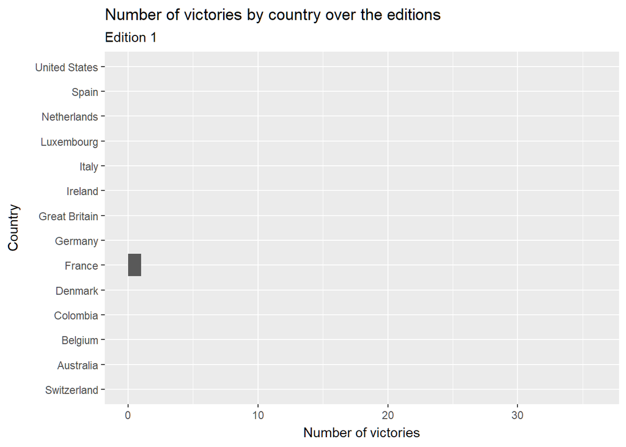

```r
# Plot and animate bar chart
tdf_winners_2 %>%
  ggplot(aes(x=nationality, y=n.victories)) +
  geom_col() +
  coord_flip() +
  labs(y="Number of victories", x="Country", title="Number of victories by country over the editions", subtitle="Edition {frame}") +
  transition_manual(edition)
```

## Make it pretty

Let’s give to the plot just a bit more of style by editing the theme.

```r
# Store animated -pretty- bar plot
animated_bar_plot <-
  tdf_winners_2 %>%
  ggplot(aes(x=nationality, y=n.victories)) +
  geom_col(fill = "white", color="white", size=1.05, width=0.1) +
  geom_text(data=tdf_winners_2 %>% filter(n.victories > 0),
    aes(label=n.victories, x=nationality, y=(n.victories+0.75)), fontface="bold", size = 3) +
  coord_flip() +
  # Add custom image on top of the column
  #geom_image(aes(image = img, y=n.victories+1.75)) +
  labs(y="", x="", title="Number of victories by country",
       subtitle="Tour de France - {frame} Edition") +
  theme_classic() +
  theme(text = element_text(family="mono"),
        panel.background = element_rect(fill = "#fbad29"),
        plot.background = element_rect(fill = "#fbad29"),
        axis.ticks = element_blank(),
        plot.title = element_text(face="bold", colour="black", size=24),
        plot.subtitle = element_text(face="bold", colour="white", size=18),
        axis.text.y = element_text(face="bold", size=15, color="white", margin=margin(0.1,5,0.1,0.1,"mm")),
        axis.text.x = element_text(face="bold", color="black", size=15),
        axis.line.y = element_blank(),
        axis.line.x = element_line(color="black"),
        axis.title.x = element_text(face="bold", color="white", size=15),
        plot.margin = margin(0.5, 0.5, 0.5, 0.5, "cm")
        ) +
  transition_manual(frames=edition)
```

# Animate and export

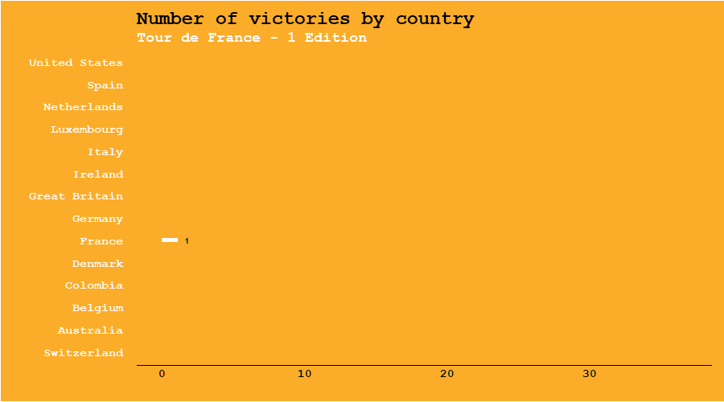

```r
animate(animated_bar_plot, width=900, height=500,
        end_pause=20, nframes=106, fps=10)
```

```r
anim_save("TDF.gif")
```

## Notes

Note that here we used “transition_manual()” from the gganimate package. A better way would be to use “transition_state()”. This cannot applied here because data is not organized in a way that reports countries with no victories on a certain year. The next step would be to expand the dataset by including also countries with zero victories for each year where they are missing.

This next chunks of code create a more comprehensive dataset, where for each year each countries is listed along with the number of victories (even if they had 0 victories).

```r
#### Preparation ####

# For the outer loop, arrange an empty list that will be used to store the result of each edition (this loop is the same performed above)
ed_list <- list()

# For the inner loop (this is new, it add missing countries when victories are zero), create a vector with countries names
# NB: use str_trim() to remove white space present at the start of each country name
# Remove the whitespace at the beginning of each country name from the original dataset
tdf_winners$nationality <- stringr::str_trim(tdf_winners$nationality)
# Save list of countries in a separate list
countries <- stringr::str_trim(unique(tdf_winners$nationality)); countries

#### Iterate to re-arrange data ####

# Iterate over the original dataset
for (ed in (1:max(tdf_winners$edition))) {
  # create the df for a specific range of editions
  df_ed <- tdf_winners %>%
    filter(edition %in% c(1:ed)) %>%
    group_by(nationality) %>%
    summarise(n.victories = n())
  # add to the df the number of the edition (ie the loop index)
  df_ed$edition <- ed

  # Check presence and add countries if not present
  # First, arrange temp vars for the loop
  # Initialise i index
  i = 1
  # Arrange an empty list and an empty df
  supp_info_list <- list()
  supp_info_df <- data.frame()
  # Iterate over countries vector
  for (c in countries) {
    if (!(c %in% stringr::str_trim(df_ed$nationality))) {
      supp_info <- data.frame(nationality = c, n.victories = as.integer(0), edition = as.integer(df_ed$edition[1]))
      print(supp_info)
      supp_info_list[[i]] <- supp_info
      i = i + 1
    }
  }
  # Bind missing countries in a comprehensive df
  supp_info_df <- bind_rows(supp_info_list)

  # Bind supplementary info with main df of the edition
  df_ed_full <- data.frame()
  df_ed_full <- bind_rows(df_ed, supp_info_df)

  # store the final df for the edition into the list
  ed_list[[ed]] <- df_ed_full
}
```

```r
#### Review and merge data ####

# In the end this now contains a list of dfs complete with all countries even if when they have 0 victories, for instance:
ed_list[1:3]
```

```
## [[1]]
## # A tibble: 14 x 3
##    nationality   n.victories edition
##    <chr>               <int>   <int>
##  1 France                  1       1
##  2 Luxembourg              0       1
##  3 Belgium                 0       1
##  4 Italy                   0       1
##  5 Switzerland             0       1
##  6 Spain                   0       1
##  7 Netherlands             0       1
##  8 United States           0       1
##  9 Ireland                 0       1
## 10 Denmark                 0       1
## 11 Germany                 0       1
```

[output cut: 41 more lines]

```r
# Merge all them together using bind_rows() from dplyr
tdf_winners_3 <- bind_rows(ed_list)
```

```r
# Inspect head and tail
head(tdf_winners_3); tail(tdf_winners_3)
```

```
## # A tibble: 6 x 3
##   nationality n.victories edition
##   <chr>             <int>   <int>
## 1 France                1       1
## 2 Luxembourg            0       1
## 3 Belgium               0       1
## 4 Italy                 0       1
## 5 Switzerland           0       1
## 6 Spain                 0       1
```

```
## # A tibble: 6 x 3
##   nationality   n.victories edition
##   <chr>               <int>   <int>
## 1 Italy                  10     106
## 2 Luxembourg              5     106
## 3 Netherlands             2     106
## 4 Spain                  12     106
## 5 Switzerland             2     106
## 6 United States          10     106
```

```r
# Inspect 1st and last edition
tdf_winners_3 %>% filter(edition == 1)
```

```
## # A tibble: 14 x 3
##    nationality   n.victories edition
##    <chr>               <int>   <int>
##  1 France                  1       1
##  2 Luxembourg              0       1
##  3 Belgium                 0       1
##  4 Italy                   0       1
##  5 Switzerland             0       1
##  6 Spain                   0       1
##  7 Netherlands             0       1
##  8 United States           0       1
##  9 Ireland                 0       1
## 10 Denmark                 0       1
## 11 Germany                 0       1
## 12 Australia               0       1
## 13 Great Britain           0       1
## 14 Colombia                0       1
```

```r
tdf_winners_3 %>% filter(edition == max(edition))
```

```
## # A tibble: 14 x 3
##    nationality   n.victories edition
##    <chr>               <int>   <int>
##  1 Australia               1     106
##  2 Belgium                18     106
##  3 Colombia                1     106
##  4 Denmark                 1     106
##  5 France                 36     106
##  6 Germany                 1     106
##  7 Great Britain           6     106
##  8 Ireland                 1     106
##  9 Italy                  10     106
## 10 Luxembourg              5     106
## 11 Netherlands             2     106
## 12 Spain                  12     106
## 13 Switzerland             2     106
## 14 United States          10     106
```

```r
# Check nationality are coherent with no difference due to, eg, white spaces
unique(tdf_winners_3$nationality)
```

```
##  [1] "France"        "Luxembourg"    "Belgium"       "Italy"
##  [5] "Switzerland"   "Spain"         "Netherlands"   "United States"
##  [9] "Ireland"       "Denmark"       "Germany"       "Australia"
## [13] "Great Britain" "Colombia"
```

```r
# Inspect no. of countries per edition: are there 14 countries for each edition?
tdf_winners_3 %>% group_by(edition) %>% summarise(n()) # yes
```

```
## # A tibble: 106 x 2
##    edition `n()`
##      <int> <int>
##  1       1    14
##  2       2    14
##  3       3    14
##  4       4    14
##  5       5    14
##  6       6    14
##  7       7    14
##  8       8    14
##  9       9    14
## 10      10    14
## # ... with 96 more rows
```